# Lab 2 - Checkpoint 4

Marcos Nascimento (marcosantonio@copin.ufcg.edu.br)

Abril 25, 2018

# Como são as buscas no Wikimedia?

## Coleção de dados

Nossa iniciativa de investigar como são as buscas no Wikimedia iniciou realizando a coleta dos dados. Os dados foram coletados por meio do registro de logs de eventos disponibilizados pela própria Wikimedia na [internet](https://github.com/wikimedia-research/Discovery-Hiring-Analyst-2016). Primeiramente, um refinamento dos dados foi realizado com o objetivo de gerar novas variáveis que pudessem extrair algumas informações valiosas. Tais variáveis, foram utilizadas como fonte de informação para investigar as questões de pesquisa deste relatório.

```r
#todas as buscas e navegações de busca
buscas = read_csv(here::here("data/search_data.csv")) %>%
    mutate(day=round_date(session_start_date, unit = "day"))
```

## Contexto da pesquisa e questões de pesquisa

Este relatório tem como objetivo responder algumas questões importantes das buscas no Wikimedia. Nós observamos como se comportam as buscas e as navegações de buscas considerando duas categorias principais. Essas categorias diferenciam dois grupos principais de sessões de usuários durante buscas e navegações. Nosso relatório é animado pelas seguintes questões de pesquisa (QP):

**QP1:** Qual é a taxa de cliques geral diária? Como ela varia entre os grupos A e B?

**QP2:** Quais resultados os usuários tendem a tentar primeiro? Como isso muda no dia-a-dia?

**QP3:** Qual é a taxa de resultados zero geral diária? Como ela varia entre os grupos A e B?

**QP4:** Vamos assumir que a duração da sessão de busca seja aproximadamente o tempo entre o primeiro evento de busca e o último evento de busca da sessão. Como a duração da sessão se relaciona com o número de cliques?

## Distribuição dos dados

Como um passo inicial, nós realizamos a exploração e a descrição das variáveis utilizadas para responder cada QP. O processo de exploração e descrição envolveu o estudo da distribuição destas variáveis, em termos de centralidade, extremos, concentração e simetria. Tal processo, ajudou a descobrir coisas surpreendentes ou estranhas, bem como, auxiliar a tomada de decisão sobre esses contornos.

### Visualizando as distribuições das variáveis de QP1

```r
buscas %>%
  subset(select = c(group)) %>%
  summary()
```

```
##     group
##  Length:136234
##  Class :character
##  Mode  :character
```

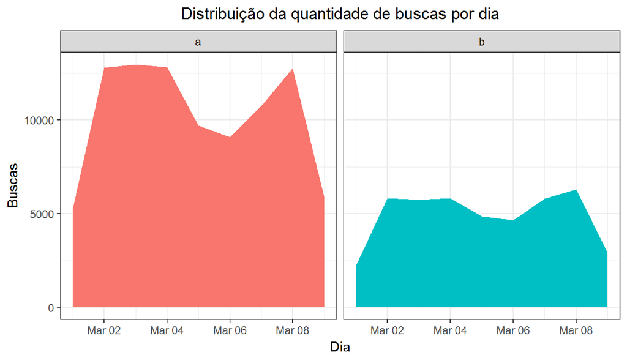

```r
#group
buscas %>%
    count(day, group) %>%
    ggplot(aes(x=day, y=n, fill=group)) +
    geom_area() +
    labs(title ="Distribuição da quantidade de buscas por dia",
         x="Dia",
         y="Buscas") +
    facet_grid(~ group) +
    theme(plot.title = element_text(hjust = 0.5), legend.position="none")
```

A medida *num_clicks*, por outro lado, fornece uma ideia da quantidade de cliques realizados pelos usuário durante a sessão. Tal medida é capaz de fornecer informações com respeito ao interesse do usuário quando uma lista de índices lhe é apresentada durante uma busca. No gráfico abaixo podemos observar, segundo a distribuição da quantidade de cliques, pontos importantes quanto extremos e concentração. Quanto a concentração, pudemos observar no gráfico de pontos abaixo, uma concentração bastante representativa de quantidade de cliques entre 0-10 pela escala logarítimica. Quanto aos extremos, podemos observar ligeiramente uma alta quantidade de cliques (36) no grupo A. Além disso, pudemos perceber uma alta quantidade de sessões de busca onde os usuários não realizaram nenhum clique. Esse comportamento é comum em ambos os grupos.

```r
buscas %>%
  subset(select = c(num_clicks)) %>%
  summary()
```

```
##    num_clicks
##  Min.   : 0.0000
##  1st Qu.: 0.0000
##  Median : 0.0000
##  Mean   : 0.2937
##  3rd Qu.: 0.0000
##  Max.   :36.0000
```

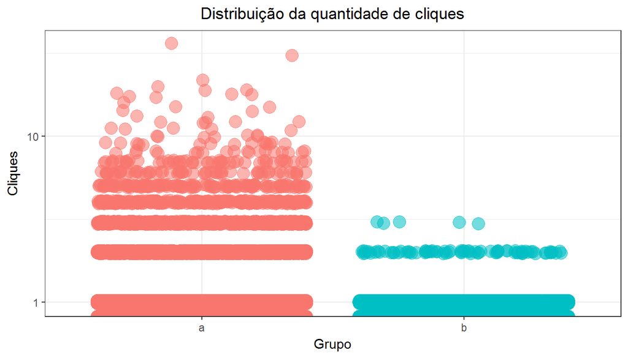

```r
#num_clicks
buscas %>%
    ggplot(aes(x = group, y = num_clicks)) +
    geom_jitter(aes(alpha = .4, width = .2, size = .8, color = group)) +
    scale_y_log10() +
    ggtitle("Distribuição da quantidade de cliques") +
    xlab("Grupo") +
    ylab("Cliques") +
  theme(plot.title = element_text(hjust = 0.5), legend.position="none")
```

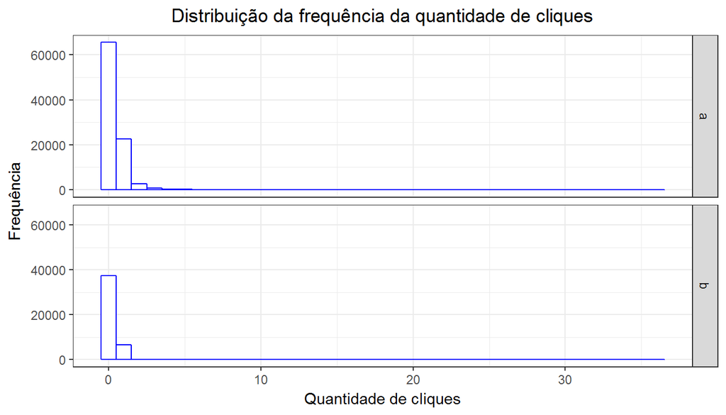

```r
buscas %>%
    ggplot(aes(x= num_clicks)) +
    geom_histogram(binwidth = 1, fill = "white", color = "blue") +
    facet_grid(group ~ .) +
    ggtitle("Distribuição da frequência da quantidade de cliques") +
    xlab("Quantidade de cliques") +
    ylab("Frequência") +
  theme(plot.title = element_text(hjust = 0.5), legend.position="none")
```

Ainda, nós observamos como a frequência da quantidade diária de cliques se comporta. Nós pudemos observar no gráfico abaixo praticamente as mesmas conclusões acima. O gráfico abaixo mostra que a contagem da quantidade de cliques são praticamente as mesmas durante todos os dias de observação. É importante ter em mente que, os dias 1 e 9 de março apresentam as menores quantidades por um simples motivo. Nestes dias, a observação das buscas não foi feita durante um intervalo completo de 24 horas.

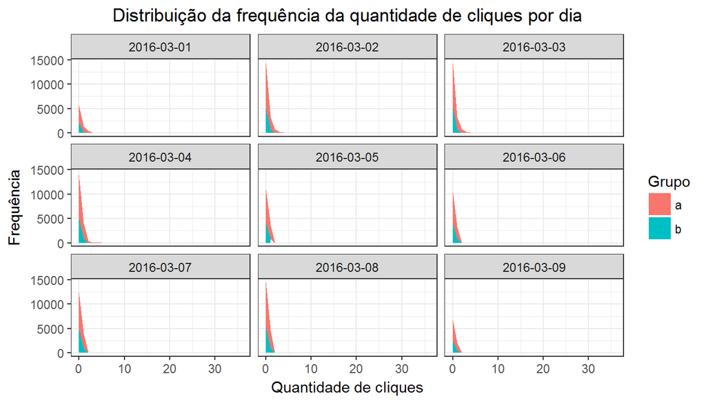

```r
buscas %>%
    count(day, group, num_clicks) %>%
    ggplot(aes(x = num_clicks, y=n, fill=group)) +
    geom_area() +
    facet_wrap(~ day) +
    labs(title ="Distribuição da frequência da quantidade de cliques por dia",
         x="Quantidade de cliques",
         y="Frequência",
         fill="Grupo") +
  theme(plot.title = element_text(hjust = 0.5))
```

### Visualizando as distribuições das variáveis de QP2

Com o objetivo de responder **QP2**, nós utilizamos duas variáveis presentes no nosso data set: *first_click* e *results*. A medida principal que fornece informação de qual índice é verificado primeiro pelos usuários é a medida *first_click*. Contudo, é importante verificar também a medida *results*. Esta medida basicamente informa a quantidade de resultados retornados para uma busca específica. A contagem de frequência dos valores da medida *first_click* revelou que, na maioria das buscas, os usuários tentam o primeiro resultado mostrado. O gráfico de histograma abaixo corrobora com nossas conclusões. Note que, a maior contagem refere-se ao índice 1.

```r
buscas %>%
  subset(select = c(first_click)) %>%
  summary()
```

```
##   first_click
##  Min.   :   1.00
##  1st Qu.:   1.00
##  Median :   1.00
##  Mean   :   3.92
##  3rd Qu.:   2.00
##  Max.   :4103.00
##  NA's   :103040
```

Além disso, é importante também notar outros dois pontos. O primeiro que, existe uma alta concentração de `NA`’s (76%) em nosso data set. De fato, nosso data set é composto não apenas de buscas mas também de navegações em sessões de buscas. E o segundo que, um índice exorbitantemente alto (4103) parece ter sido experimentado pelos usuários durante as buscas. Uma hipótese anédota é que, este índice tenha sido alcançado e experimentado não por um usuário e sim por um robô.

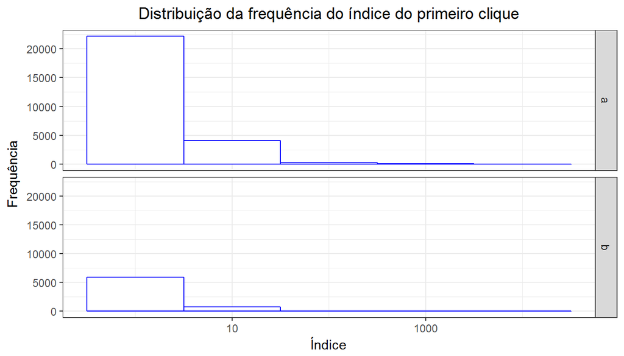

```r
#first_click
buscas %>%
    ggplot(aes(x= first_click)) +
    geom_histogram(binwidth = 1, fill = "white", color = "blue") +
    facet_grid(group ~ .) +
    scale_x_log10() +
    ggtitle("Distribuição da frequência do índice do primeiro clique") +
    xlab("Índice") +
    ylab("Frequência") +
  theme(plot.title = element_text(hjust = 0.5))
```

A medida *results* apresenta um comportamento similar. A maioria da quantidade de resultados retornados pelas bucas está entre 0-40 em ambos os grupos. O gráfico de histograma abaixo mostra isso ligeiramente. Contudo, é importante também notar a incidência de algumas outras quantidade de resultados não usuais. Isso caracteriza o enviesamento à direita do gráfico.

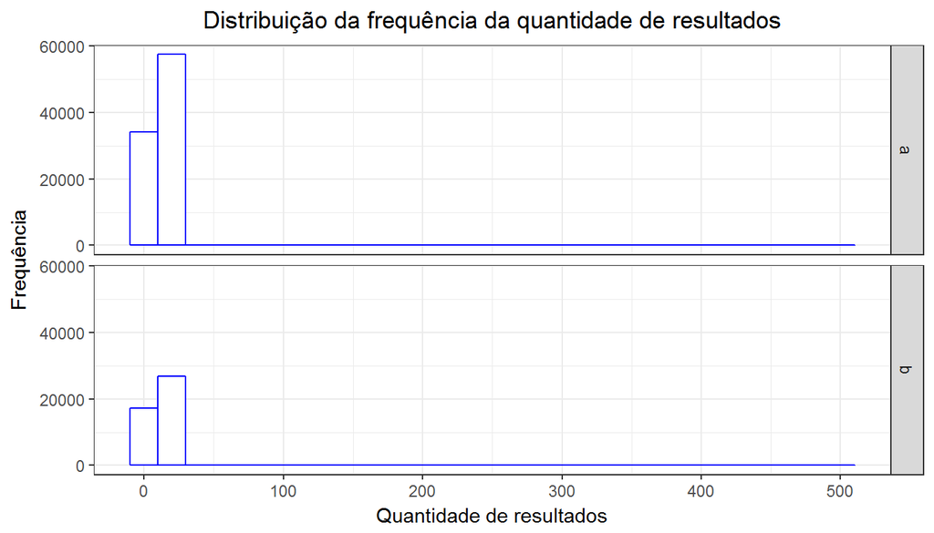

```r
#results
buscas %>%
    ggplot(aes(x= results)) +
    geom_histogram(binwidth = 20, fill = "white", color = "blue") +
    facet_grid(group ~ .) +
    ggtitle("Distribuição da frequência da quantidade de resultados") +
    xlab("Quantidade de resultados") +
    ylab("Frequência") +
  theme(plot.title = element_text(hjust = 0.5))
```

Ainda, nós observamos como o índice do primeiro clique está relacionado a quantidade de resultados retornados. Nós pudemos observar no gráfico abaixo que quatro dias apresentaram alguns picos de resultados retornados. O gráfico abaixo mostra que, nos dias 3, 6, 7 e 8 de março alguns usuários, iniciaram buscas com o primeiro clique, com altas quantidades de resultados. Isto aconteceu, sobretudo, pela maior parte do tempo pelas buscas do grupo A.

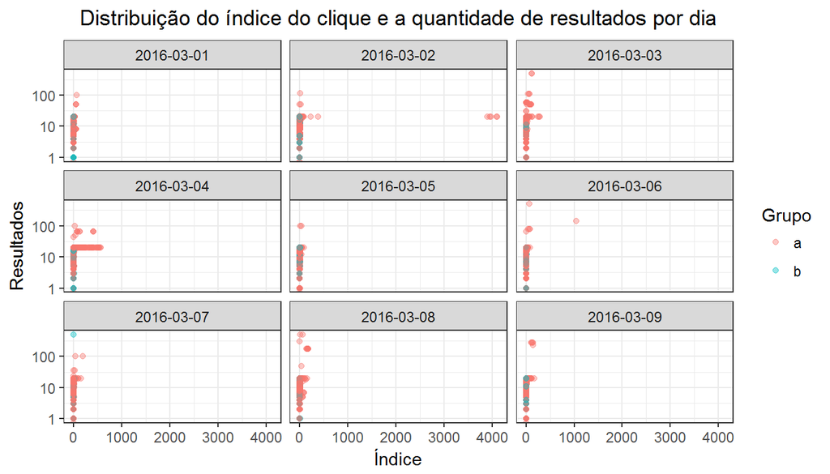

```r
#paralelo first_click e results
buscas %>%
    filter(first_click != 'NA') %>%
    ggplot(aes(x = first_click, y=results, color=group)) +
    geom_jitter(width = .2, alpha=.4) +
    scale_y_log10() +
    facet_wrap(~ day) +
    labs(title="Distribuição do índice do clique e a quantidade de resultados por dia", x="Índice", y="Resultados", color="Grupo") +
  theme(plot.title = element_text(hjust = 0.5))
```

### Visualizando as distribuições das variáveis de QP3

Com o objetivo de responder **QP3**, nós utilizamos três variáveis presentes no nosso data set: *group*, *results* e *session_start_date*. Levando em consideração o fato de que já observamos as medidas *group* e a medida *results*, nós conduzimos um estudo da medida *results* de um outro ângulo. Nós realizamos uma análise minuciosa de como a distribuição de *results* se comportou em cada um dos grupos. Nós pudemos observar, no gráfico abaixo quanto a concentração que, uma parte dos valores de *results* diário se concentra em 0 de forma constante. Contudo, a concentração mais relevante se mantém em torno de 10 resultados. Esse gráfico corrobora com nossas afirmações quanto ao histograma da contagem de *results*. Quanto aos extremos, podemos ainda observar que, ligeiramente o grupo B supera o grupo A em quantidade de resultados apenas em dois dias: 1º e 7º de março.

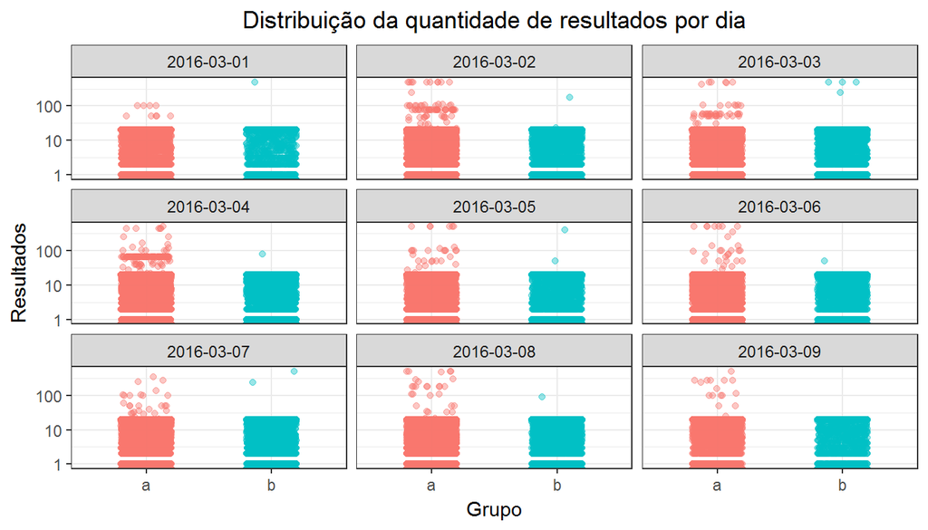

```r
buscas %>%
    ggplot(aes(x=group, y=results, color=group)) +
    geom_jitter(width = .2, alpha=.4) +
    facet_wrap(~ day) +
    scale_y_log10() +
    labs(title="Distribuição da quantidade de resultados por dia", x="Grupo", y="Resultados", color="Grupo") +
    theme(plot.title = element_text(hjust = 0.5), legend.position="none")
```

Também, nós contamos a incidência de buscas com a quantidade de resultados igual a zero. Nós ligeiramente verificamos que o grupo A supera o grupo B. Os gráficos abaixo revelaram que, idependente do dia, as bucas realizadas pelo grupo B possuem menos quantidade de resultados iguais a zero do que o grupo A.

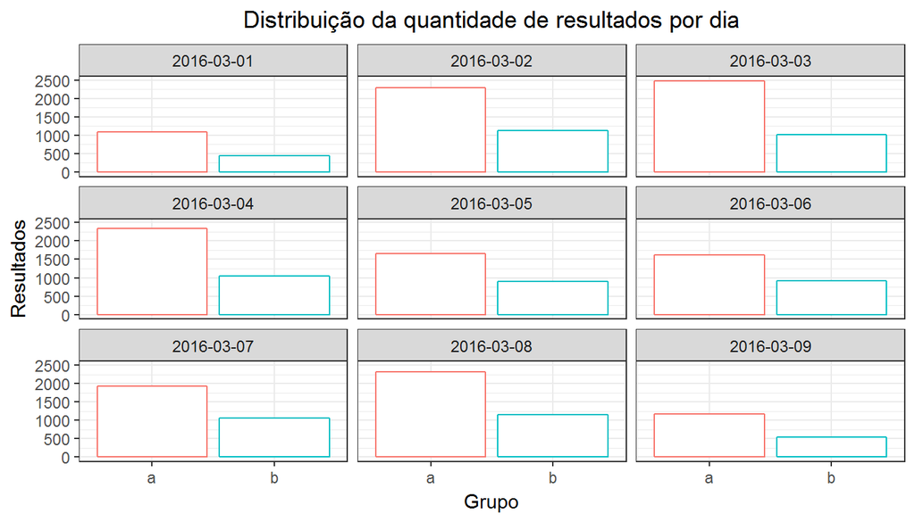

```r
buscas %>%
    filter(results == 0) %>%
    count(day, group) %>%
    ggplot(aes(x=group, y=n, color=group)) +
    geom_col(fill="white") +
    facet_wrap(~ day) +
    labs(title="Distribuição da quantidade de resultados por dia", x="Grupo", y="Resultados", color="Grupo") +
    theme(plot.title = element_text(hjust = 0.5), legend.position="none")
```

### Visualizando as distribuições das variáveis de QP4

Com o objetivo de responder **QP4**, nós construímos uma nova variável chamada *session_length*. Esta variável basicamente informa quanto tempo durou a sessão de busca do usuário. Nós pudemos observar, quanto à duração das sessões dos grupos A e B, que elas não são as mesmas. De fato, as sessões do grupo A são mais demoradas do que as do grupo B. Isto é claramente visível, pelos extremos de durações observados no gráfico abaixo, nos dias 3, 4, 7, 8 e 9 de março. Além disso, nós também pudemos observar quanto a concentração que, a maior parte das durações se concentra em torno de 0 segundos.

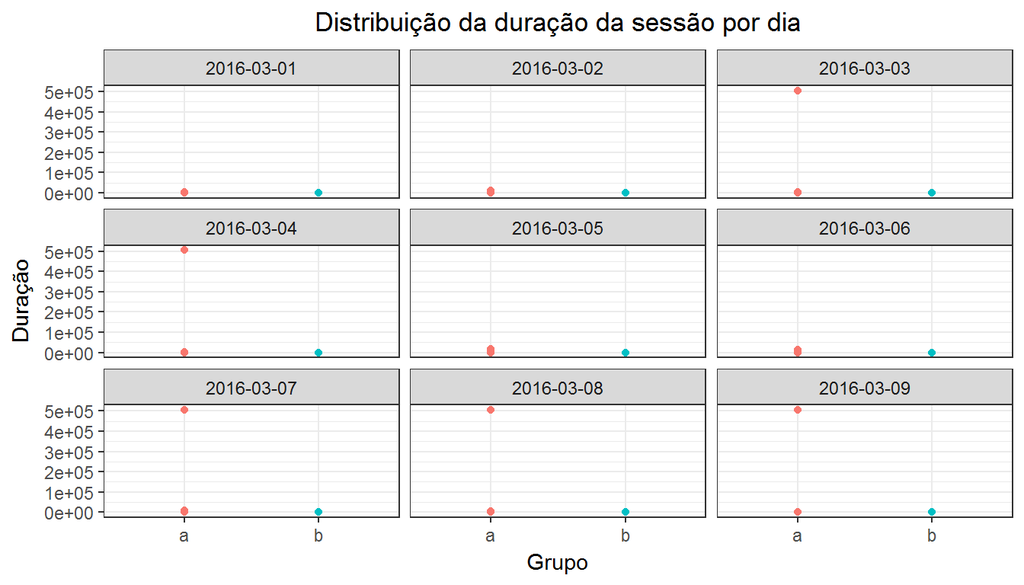

```r
buscas %>%
    group_by(session_id) %>%
    mutate(session_length=as.numeric(
        difftime(max(session_start_date),
                 min(session_start_date),
                 units = c("secs")))
        ) %>%
    ggplot(aes(x=group,
               y=session_length,
               color=group)) +
    geom_point() +
    facet_wrap(~ day) +
    ggtitle("Distribuição da duração da sessão por dia") +
    xlab("Grupo") +
    ylab("Duração") +
    theme(plot.title = element_text(hjust = 0.5), legend.position="none")
```

## Resultados e discussão

Com o objetivo de responder **QP1**, nós observamos a distribuição das proporções de sessões de buscas sobre duas perspectivas: tempo e distribuição. Na perspectiva de tempo os dados revelaram que, as proporções de sessões de buscas diárias com clique do grupo A, são superiores as sessões do grupo B. O gráfico de linha do tempo abaixo, mostra isso claramente.

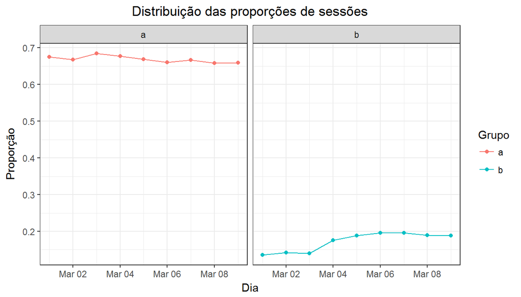

```r
#What is our daily overall clickthrough rate? How does it vary between the groups?
all_sessions = buscas %>%
    distinct(session_id, .keep_all=TRUE) %>%
    count(day, group)

clicked_sessions = buscas %>%
    filter(num_clicks >= 1) %>%
    distinct(session_id, .keep_all=TRUE) %>%
    count(day, group) %>%
    merge(all_sessions, by=c('day','group'))

colnames(clicked_sessions) = c("day", "group", "clicked_sessions", "all_sessions")

clicked_sessions = clicked_sessions %>%
    mutate(click_rate=clicked_sessions/all_sessions)

clicked_sessions %>%
    ggplot(aes(x = day, y = click_rate, color = group)) +
    geom_line() +
    geom_point() +
    facet_grid(~ group) +
    labs(title="Distribuição das proporções de sessões", x="Dia",
         y="Proporção", color="Grupo") +
    theme(plot.title = element_text(hjust = 0.5))
```

```r
tapply(clicked_sessions$click_rate,
       clicked_sessions$group,
       median)
```

```
##         a         b
## 0.6675462 0.1883013
```

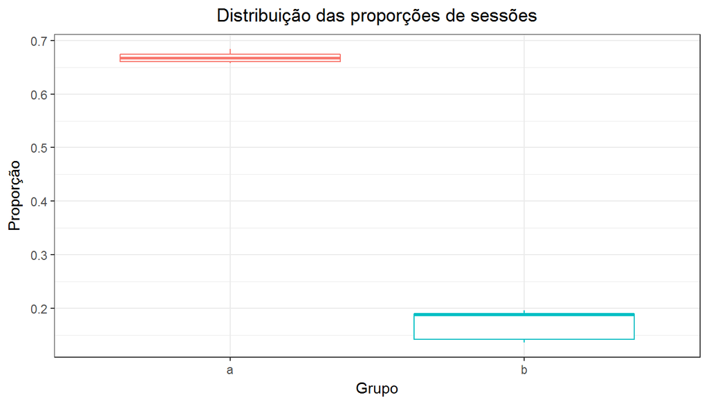

```r
clicked_sessions %>%
    ggplot(aes(x= group,
               y = click_rate,
               color= group)) +
    geom_boxplot(varwidth=T) +
    labs(title="Distribuição das proporções de sessões",
         x="Grupo", y="Proporção") +
    theme(plot.title = element_text(hjust = 0.5), legend.position="none")
```

Com o objetivo de responder **QP2**, nós observamos a distribuição da variável de *first_click*. Nós pudemos observar no gráfico abaixo que, apesar de alguns outliers, as buscas realizadas em ambos os grupos possuem os mesmos valores medianos do índice de primeiro clique (1). Isto quer dizer que, independente do grupo de busca, os usuários tendem a tentar os primeiros índices mostrados pela máquina de busca. Além disso, vale observar que, este comportamento é mantido pelos usuários independente do dia de observação. Em resposta a **QP2**, podemos concluir com base nos dados que, os resultados que os usuários tendem a experimentar primeiro são os mostrados no topo da lista de resultados. Também, esse comportamento é mantido independente do dia da observação.

```r
tapply(buscas$first_click,
       buscas$group,
       median, na.rm=TRUE)
```

```
## a b
## 1 1
```

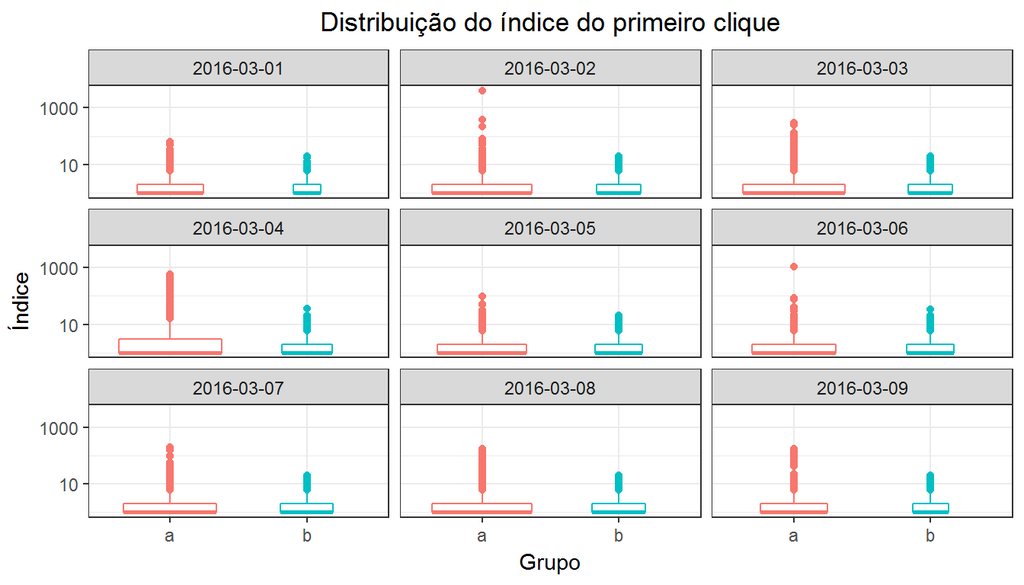

```r
#Which results do people tend to try first? How does it change day-to-day?
buscas %>%
    filter(first_click != 'NA') %>%
    ggplot(aes(x = group, y = first_click, color=group)) +
    geom_boxplot(varwidth = T) +
    scale_y_log10() +
    facet_wrap(~ day) +
    labs(title="Distribuição do índice do primeiro clique", x="Grupo",
         y="Índice") +
    theme(plot.title = element_text(hjust = 0.5), legend.position="none")
```

Levando em conta não só o caso médio mas também o pior caso, nós conduzimos uma investigação com base nos valores máximos da variável de *first_click*. Nesta análise, os dados revelaram que, os usuários do grupo A, tendem a experimentar os maiores índices retornados pela máquina de busca. De fato, no gráfico abaixo da linha do tempo, pudemos observar que as buscas no grupo A obtiveram altos índices experimentados pelos usuários. Isto aconteceu, sobretudo, particularmente nos dias 2, 4 e 6 de março.

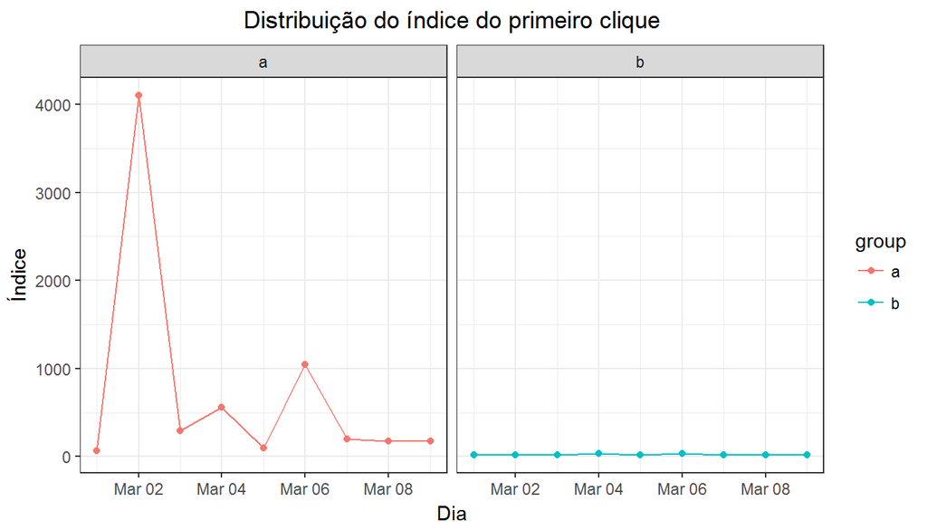

```r
first_click_time = buscas %>%
    filter(first_click != 'NA') %>%
    group_by(day, group) %>%
    summarise(first_click=max(first_click))

#first_click considering their highest values
first_click_time %>%
    ggplot(aes(x = day, y = first_click, color = group)) +
    geom_line() +
    geom_point() +
    facet_grid(~ group)  +
    labs(title="Distribuição do índice do primeiro clique", x="Dia",
         y="Índice") +
    theme(plot.title = element_text(hjust = 0.5))
```

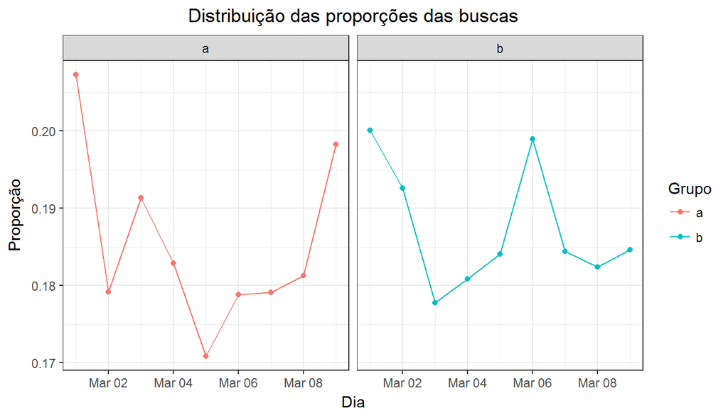

```r
#What is our daily overall zero results rate? How does it vary between the groups?
all_sessions = buscas %>%
    count(day, group)

zero_results_sessions = buscas %>%
    filter(results == 0) %>%
    count(day, group) %>%
    merge(all_sessions, by=c('day','group'))

colnames(zero_results_sessions) = c("day", "group", "zero_results_sessions", "all_sessions")

zero_results_sessions = zero_results_sessions %>%
    mutate(zero_rate=zero_results_sessions/all_sessions)

zero_results_sessions %>%
    ggplot(aes(x = day, y = zero_rate, color = group)) +
    geom_line() +
    geom_point() +
    facet_grid(~ group) +
    labs(title="Distribuição das proporções das buscas", x="Dia",
         y="Proporção", color="Grupo") +
    theme(plot.title = element_text(hjust = 0.5))
```

Na perspectiva de distribuição nós observamos o gráfico de box-plot. Observando o gráfico abaixo é fácil perceber que ele corrobora com nossas conclusões. De fato, olhando sobre a perspectiva de distribuição, as proporções de buscas do grupo A são ligeiramente um pouco inferiores do que as do grupo B. Nós observamos que as buscas do grupo B (0.184) apresentam maior mediana de proporções em relação as buscas do grupo A (0.181). Em resposta a **QP3**, podemos concluir com base nos dados que, existe uma diferença entre os grupos A e B quanto a proporção de buscas diárias com resultados iguais a zero. Além disso, essas taxas apresentam uma maior variação no grupo A. Isso é facilmente notado pela altura do box-plot de A em relação ao de B.

```r
tapply(zero_results_sessions$zero_rate,
       zero_results_sessions$group,
       median)
```

```
##         a         b
## 0.1812632 0.1844375
```

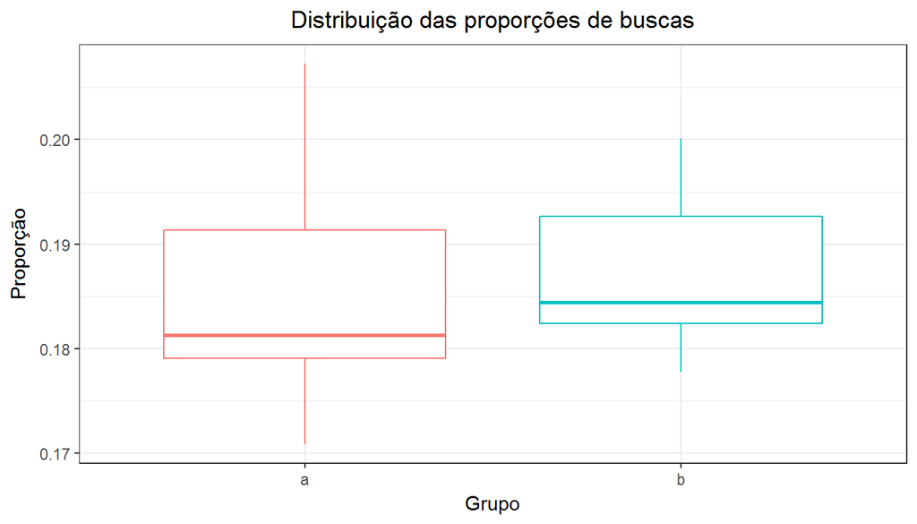

```r
zero_results_sessions %>%
    ggplot(aes(x= group,
               y = zero_rate,
               color= group)) +
    geom_boxplot(varwidth=T) +
    labs(title="Distribuição das proporções de buscas",
         x="Grupo", y="Proporção") +
    theme(plot.title = element_text(hjust = 0.5), legend.position="none")
```

Com o objetivo de responder **QP4**, nós observamos como a distribuição da duração da sessão de busca se relaciona com o número de cliques do usuário. Os dados reveleram que não há uma relação forte entre estas variáveis. De fato, nós pudemos observar que, o tamanho da duração da sessão não cresce ou diminui a medida que o número de cliques do usuário aumenta.

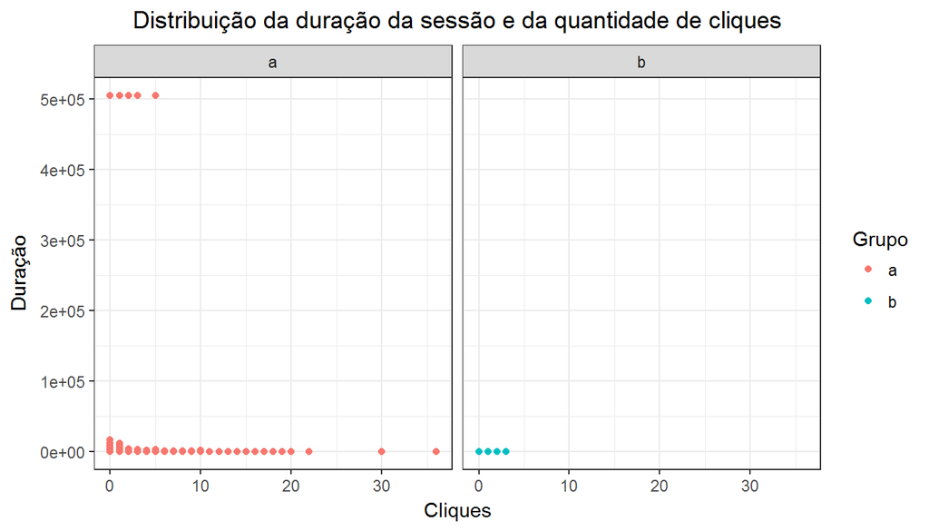

```r
buscas2 = buscas %>%
    group_by(session_id) %>%
    mutate(session_length=as.numeric(
        difftime(max(session_start_date),
                 min(session_start_date),
                 units = c("secs")))
        )

buscas2 %>%
    ggplot(aes(x=num_clicks,
               y=session_length,
               color=group)) +
    geom_point() +
    facet_wrap(~ group) +
    labs(title="Distribuição da duração da sessão e da quantidade de cliques",
         x="Cliques", y="Duração", color="Grupo") +
    theme(plot.title = element_text(hjust = 0.5))
```

Com o objetivo de medir essa relação, nós utilizamos o cálculo dos coeficientes de correlação. Os resultados mostram a existência de uma relação monotônica inversa e fraca entre as variáveis tanto para o grupo A (Spearman’s *rho* de -0.227) quanto para o grupo B (Spearman’s *rho* de -0.134). Em resposta a **QP4**, podemos concluir com base nos dados que, existe uma relação entre a duração da sessão de busca e a quantidade de cliques. Contudo, essa relação é inversa e fraca (~0).

```r
buscas2 %>%
  group_by(group) %>%
  summarise(pearson = cor(session_length, num_clicks, method = "pearson"),
            spearman = cor(session_length, num_clicks, method = "spearman"),
            kendall = cor(session_length, num_clicks, method = "kendall"))
```

| group | pearson | spearman | kendall |
| --- | --- | --- | --- |
| a | -0.00358093 | -0.2266314 | -0.1820272 |
| b | -0.07654785 | -0.1343928 | -0.1265249 |

## Conclusão

Este relatório tinha como objetivo identificar como são as buscas no Wikimedia. Nós pudemos investigar vários aspectos das buscas considerando duas categorias principais. Nós observamos que existe uma diferença entre os grupos A e B quanto à proporção de sessões de buscas diárias com clique. Além disso, essas taxas apresentam uma maior variação no grupo B. Mais importante, os resultados revelaram que os usuários tendem a experimentar primeiro os resultados mostrados no topo da lista de resultados. Considerando o pior caso, os usuários do grupo A tendem a experimentar os maiores índices retornados pela máquina de busca. No que toca aos resultados retornados, pudemos observar que existe uma diferença entre os grupos A e B quanto a proporção de buscas diárias com resultados iguais a zero. Além disso, essas taxas apresentam uma maior variação no grupo A. Finalmente, podemos concluir que, de fato, existe uma relação entre a duração da sessão de busca e a quantidade de cliques. Contudo, essa relação é inversa e relevantemente fraca. É importante destacar que os resultados levam em consideração valores pontuais obtidos pela análise descritiva e exploratória. Neste sentido, pode ser interessante comprovar nossos achados com base estatística.